# graficas

## PRÁCTICA FINAL - FÓRMULA 1

### Conclusiones

#### Carga de datos

```python
# Importar librerías
import pandas as pd
import numpy as np
from scipy import stats
import matplotlib.pyplot as plt
import seaborn as sns
```

```python
# Cargamos el DataFrame y vemos el tipo de dato de cada columna

df=pd.read_csv('results/merged.csv')

# Convertir columnas a numéricas
df['Position'] = pd.to_numeric(df['Position'], errors='coerce').fillna(0).astype('int64')  # Reemplaza NaN con 0 y convierte a int64
df['Time/Retired'] = pd.to_numeric(df['Time/Retired'], errors='coerce')
df['Grid'] = pd.to_numeric(df['Grid'], errors='coerce').fillna(0).astype('int64')
df['Points'] = pd.to_numeric(df['Points'], errors='coerce')

'''
Los pilotos que no han terminado una carrera (Ret y dnf) se almacenan con el valor 0.
Los pilotos que empiezan una carrera desde el pitlane se almacenan con el valor 0.
Es necesario eliminar esos datos ya que alteran las conclusiones. Por ejemplo, aquellos que salen desde el pitlane (Grid = 0),
salen detrás del último en el grid. Por lo tanto suelen terminar en posiciones muy malas. Esto altera la correlación entre Grid
y Position, ya que su valor en grid es menor que 1 (el que empieza primero).
'''
df = df[df['Position'] != 0]
df = df[df['Grid'] != 0]
```

#### GRÁFICA 1: Gráfico línea MedianPitStopDuration y Position (con datos anómalos)

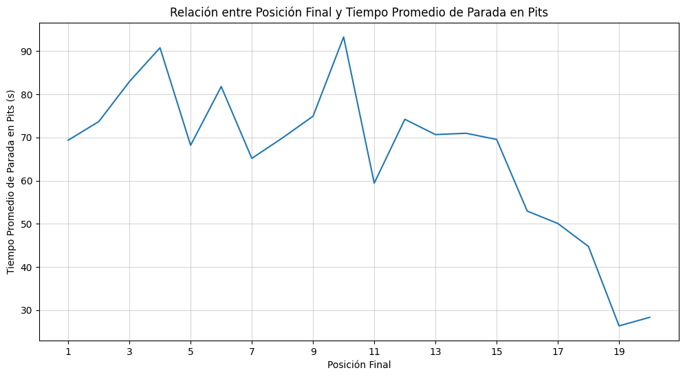

```python
# Agrupar por posición y calcular el tiempo promedio de parada en pits
df_g1 = df.groupby('Position')['MedianPitStopDuration'].mean().reset_index()

# Ordenar por posición
df_g1 = df_g1.sort_values(by='Position')

# Crear el gráfico de líneas
plt.figure(figsize=(12, 6))
plt.plot(df_g1['Position'], df_g1['MedianPitStopDuration'])

# Etiquetas y título
plt.title('Relación entre Posición Final y Tiempo Promedio de Parada en Pits')
plt.xlabel('Posición Final')
plt.ylabel('Tiempo Promedio de Parada en Pits (s)')

# Límites de los ejes
plt.xticks(range(1, int(df_g1['Position'].max()) + 1, 2))
plt.grid(True, linestyle='-', alpha=0.5)
plt.show()
```

#### GRÁFICA 2: Gráfico línea MedianPitStopDuration y Position (sin datos anómalos)

En el gráfico podemos observar que hay muchísimos datos anómalos, ya que un tiempo promedio de una parada en pits está entre 20 y 30 segundos. Por lo tanto, eliminamos aquellos datos anómalos y creamos un nuevo DataFrame filtrando los valores según el rango intercuartílico (como hemos aprendido en clase)

```python
# Calcular el primer y tercer cuartil de la columna MedianPitStopDuration
q1 = df['MedianPitStopDuration'].quantile(0.25)
q3 = df['MedianPitStopDuration'].quantile(0.75)

# Calcular el rango intercuartil (IQR)
iqr = q3 - q1

# Definir los límites inferior y superior para filtrar
limite_inf = q1 - 1.5 * iqr
limite_sup = q3 + 1.5 * iqr

# Filtrar el DataFrame para incluir solo valores dentro del rango IQR
df = df[(df['MedianPitStopDuration'] >= limite_inf) & (df['MedianPitStopDuration'] <= limite_sup)]
```

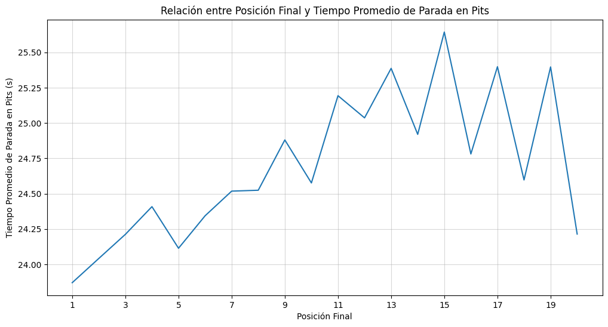

```python
# Agrupar por posición y calcular el tiempo promedio de parada en pits
df_g2 = df.groupby('Position')['MedianPitStopDuration'].mean().reset_index()

# Ordenar por posición
df_g2 = df_g2.sort_values(by='Position')

# Crear el gráfico de líneas
plt.figure(figsize=(12, 6))
plt.plot(df_g2['Position'], df_g2['MedianPitStopDuration'])

# Etiquetas y título
plt.title('Relación entre Posición Final y Tiempo Promedio de Parada en Pits')
plt.xlabel('Posición Final')
plt.ylabel('Tiempo Promedio de Parada en Pits (s)')

# Límites de los ejes
plt.xticks(range(1, int(df_g2['Position'].max()) + 1, 2))
plt.grid(True, linestyle='-', alpha=0.5)
plt.show()
```

#### GRÁFICO 3: Matriz de correlación entre diferentes variables

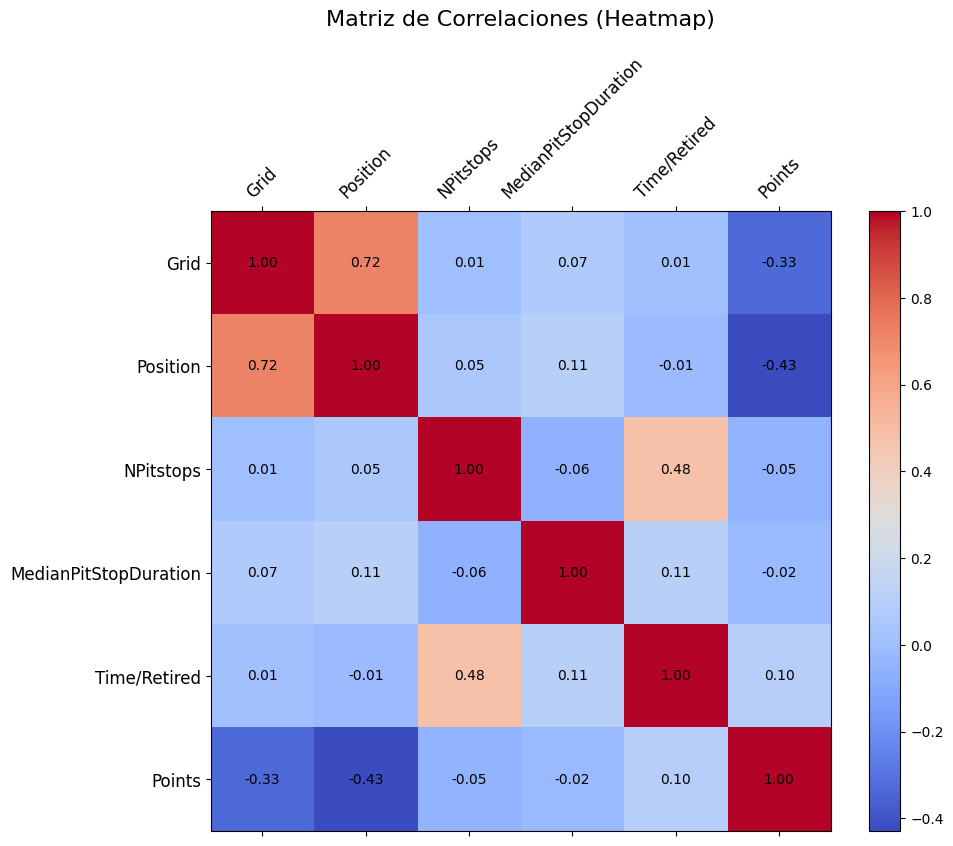

```python
columns_to_correlate = ['Grid', 'Position', 'NPitstops', 'MedianPitStopDuration', 'Time/Retired', 'Points']
df_g3 = df[columns_to_correlate]
correlation_matrix = df_g3.corr()

# Crear el heatmap
plt.figure(figsize=(10, 8))
cax = plt.matshow(correlation_matrix, cmap="coolwarm", fignum=1)

# Añadir etiquetas a los ejes
plt.xticks(range(len(columns_to_correlate)), columns_to_correlate, rotation=45, fontsize=12)
plt.yticks(range(len(columns_to_correlate)), columns_to_correlate, fontsize=12)

for (i, j), val in np.ndenumerate(correlation_matrix.values):
    plt.text(j, i, f'{val:.2f}', ha='center', va='center', color='black')

plt.colorbar(cax)
plt.title('Matriz de Correlaciones (Heatmap)', fontsize=16, pad=20)
plt.show()
```

#### GRÁFICO 4: Scatterplot Grid y Position

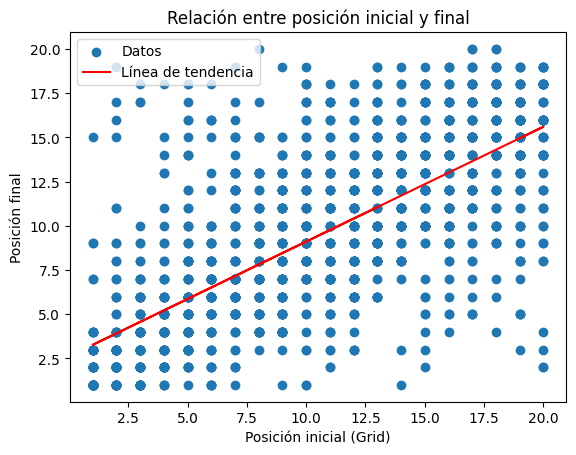

```python
x = df['Grid']
y = df['Position']

# Scatter plot
plt.scatter(x, y, label='Datos')

# Línea de tendencia
z = np.polyfit(x, y, 1)
p = np.poly1d(z)
plt.plot(x, p(x), color='red', label='Línea de tendencia')

# Personalización del gráfico
plt.xlabel('Posición inicial (Grid)')
plt.ylabel('Posición final')
plt.title('Relación entre posición inicial y final')
plt.legend()
plt.show()
```

#### GRÁFICO 5: Gráfico de barras comparativo entre Position, NPitStops y MedianPitStopDuration

```python
teams = df['Constructor'].unique()
print(teams)
```

```
['Scuderia Toro Rosso - Honda' 'Mercedes' 'Red Bull Racing - Honda'
 'Alfa Romeo Racing - Ferrari' 'Renault' 'Haas - Ferrari'
 'Williams - Mercedes' 'Ferrari' 'McLaren - Renault'
 'Racing Point - BWT Mercedes' 'AlphaTauri - Honda' 'McLaren - Mercedes'
 'Alpine - Renault' 'Aston Martin - Mercedes' 'Alfa Romeo - Ferrari'
 'Aston Martin   Aramco - Mercedes' 'Red Bull Racing - RBPT'
 'AlphaTauri - RBPT' 'AlphaTauri - Honda RBPT'
 'Red Bull Racing - Honda RBPT']
```

Como podemos observar, un mismo equipo puede cambiar de nombre. Por ejemplo, McLaren cambió de motor de Renault a Mercedes, y por ello su nombre también. Para el siguiente gráfico, cambiaré el nombre de Constructor por el nombre del equipo más simple (indicaré el nombre que pasan a tener):

- Mercedes
- Ferrari
- Red Bull Racing - Honda / Red Bull Racing - RBPT / Red Bull Racing - Honda RBPT ---> Red Bull
- McLaren - Renault / McLaren - Mercedes ---> McLaren
- Renault
- Alfa Romeo Racing - Ferrari / Alfa Romeo - Ferrari ---> Alfa Romeo
- Scuderia Toro Rosso - Honda ---> Toro Rosso
- Racing Point - BWT Mercedes ---> Racing Point
- Williams - Mercedes ---> Williams
- Haas - Ferrari ---> Haas
- AlphaTauri - Honda / AlphaTauri - RBPT / AlphaTauri - Honda RBPT ---> AlphaTauri
- Aston Martin - Mercedes / Aston Martin Aramco - Mercedes ---> Aston Martin
- Alpine - Renault ---> Alpine

```python
cambios = {
    'Red Bull Racing - Honda': 'Red Bull',
    'Red Bull Racing - RBPT': 'Red Bull',
    'Red Bull Racing - Honda RBPT': 'Red Bull',
    'McLaren - Renault': 'McLaren',
    'McLaren - Mercedes': 'McLaren',
    'Alfa Romeo Racing - Ferrari': 'Alfa Romeo',
    'Alfa Romeo - Ferrari': 'Alfa Romeo',
    'Scuderia Toro Rosso - Honda': 'Toro Rosso',
    'Racing Point - BWT Mercedes': 'Racing Point',
    'Williams - Mercedes': 'Williams',
    'Haas - Ferrari': 'Haas',
    'AlphaTauri - Honda': 'AlphaTauri',
    'AlphaTauri - RBPT': 'AlphaTauri',
    'AlphaTauri - Honda RBPT': 'AlphaTauri',
    'Aston Martin - Mercedes': 'Aston Martin',
    'Aston Martin   Aramco - Mercedes': 'Aston Martin',
    'Alpine - Renault': 'Alpine'
}

# Reemplazar los valores de la columna 'Team'
df['Constructor'] = df['Constructor'].replace(cambios)
```

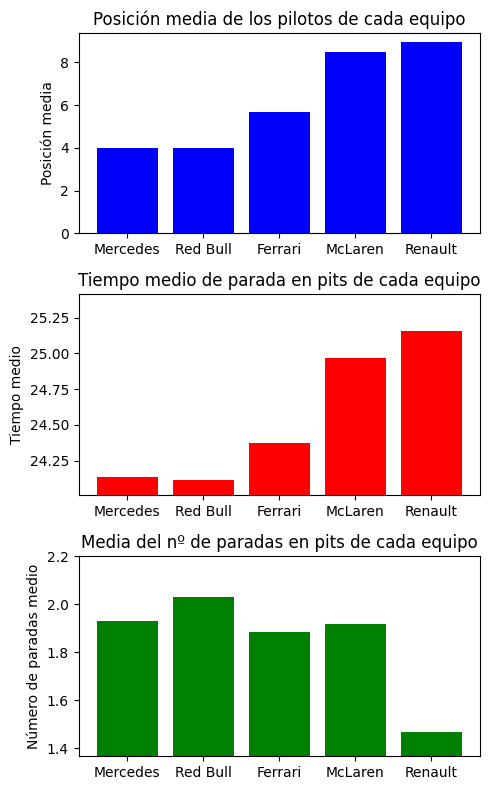

```python
'''
x: equipos por orden de mejor posición media de sus pilotos
y1: posición media de cada equipo
y2: tiempo medio de parada en pits
'''

# Calcular las métricas necesarias para cada constructor
resultados_g5 = df.groupby('Constructor').agg({
    'Position': 'mean',
    'MedianPitStopDuration': 'mean',
    'NPitstops': 'mean'
}).reset_index()

# Ordenar por posición media de menor a mayor
resultados_g5 = resultados_g5.sort_values(by='Position', ascending=True)

constructores_ordenados = resultados_g5['Constructor'].tolist()
posiciones_medias = resultados_g5['Position'].tolist()
tiempos_medios = resultados_g5['MedianPitStopDuration'].tolist()
paradas_totales = resultados_g5['NPitstops'].tolist()

# Seleccionamos los equipos con las 5 mejores posiciones
x = constructores_ordenados[:5]
y1 = posiciones_medias[:5]
y2 = tiempos_medios[:5]
y3 = paradas_totales[:5]

# Crear figura y subplots
fig, axs = plt.subplots(3, 1, figsize=(5, 8))  # 2 filas, 1 columna

# Primer gráfico de barras
axs[0].bar(x, y1, color='blue')
axs[0].set_title('Posición media de los pilotos de cada equipo')
axs[0].set_ylabel('Posición media')

# Segundo gráfico de barras
axs[1].bar(x, y2, color='red')
axs[1].set_title('Tiempo medio de parada en pits de cada equipo')
axs[1].set_ylabel('Tiempo medio')

# Ajustar el rango del eje y para mejorar la precisión
min_tiempo = min(tiempos_medios) - 0.1  # Límite inferior ligeramente menor
max_tiempo = max(tiempos_medios) + 0.1  # Límite superior ligeramente mayor
axs[1].set_ylim([min_tiempo, max_tiempo])

# Segundo gráfico de barras
axs[2].bar(x, y3, color='green')
axs[2].set_title('Media del nº de paradas en pits de cada equipo')
axs[2].set_ylabel('Número de paradas medio')

# Ajustar el rango del eje y para mejorar la precisión
min_paradas = min(paradas_totales) - 0.1  # Límite inferior ligeramente menor
max_paradas = max(paradas_totales) + 0.1  # Límite superior ligeramente mayor
axs[2].set_ylim([min_paradas, max_paradas])

# Ajustar los espacios entre subplots
plt.tight_layout()
plt.show()
```

#### GRÁFICA 6: Correlación entre Grid y Position en Mónaco (circuito urbano caracterizado por la dificultad de adelantar)

```python
# Filtramos las carreras de Mónaco desde 2019 (en 2020 se canceló por COVID)
filters = [
    (2019, 6),
    (2021, 5),
    (2022, 7),
    (2023, 6)
]

# Crear un nuevo DataFrame filtrando las filas que coincidan con las combinaciones dadas
df_g6 = df[df.apply(lambda row: (row['Season'], row['RaceNumber']) in filters, axis=1)]
```

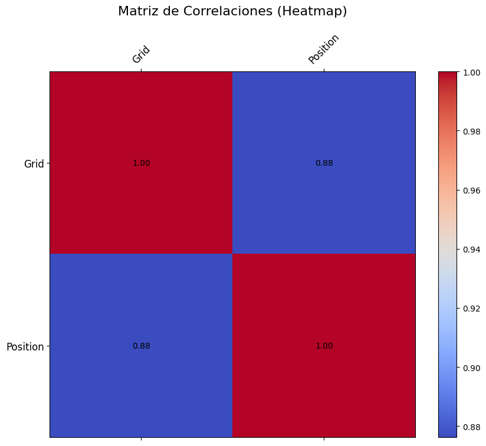

```python
columns_to_correlate = ['Grid', 'Position']

# Filtrar el DataFrame para incluir solo las columnas especificadas
heatmap_g6 = df_g6[columns_to_correlate]

# Calcular la matriz de correlación
correlation_matrix = heatmap_g6.corr()

# Crear el heatmap
plt.figure(figsize=(10, 8))
cax = plt.matshow(correlation_matrix, cmap="coolwarm", fignum=1)

plt.xticks(range(len(columns_to_correlate)), columns_to_correlate, rotation=45, fontsize=12)
plt.yticks(range(len(columns_to_correlate)), columns_to_correlate, fontsize=12)

for (i, j), val in np.ndenumerate(correlation_matrix.values):
    plt.text(j, i, f'{val:.2f}', ha='center', va='center', color='black')

plt.colorbar(cax)
plt.title('Matriz de Correlaciones (Heatmap)', fontsize=16, pad=20)
plt.show()
```

Como podemos observar, la correlación es superior a la media (Gráfico 3)

#### GRÁFICO 7: Scatterplot MedianPitStopDuration y Position

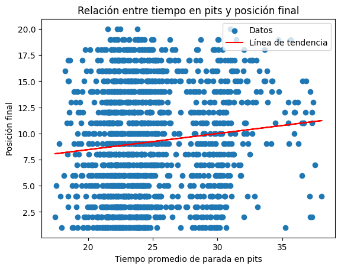

```python
x = df['MedianPitStopDuration']
y = df['Position']

# Scatter plot
plt.scatter(x, y, label='Datos')

# Línea de tendencia
z = np.polyfit(x, y, 1)
p = np.poly1d(z)
plt.plot(x, p(x), color='red', label='Línea de tendencia')

# Personalización del gráfico
plt.xlabel('Tiempo promedio de parada en pits')
plt.ylabel('Posición final')
plt.title('Relación entre tiempo en pits y posición final')
plt.legend()
plt.show()
```

#### GRÁFICO 8: Scatterplot con boxplot marginales NPitstops y MedianPitStopDuration

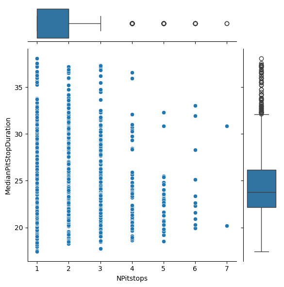

```python
x = df['NPitstops']
y = df['MedianPitStopDuration']

# Boxplots marginales
fig = plt.figure(3)
g = sns.JointGrid(x=x, y=y)
g.plot_joint(sns.scatterplot)
g.plot_marginals(sns.boxplot)
plt.show()
```